# Practice 2.1

Parker Petersen

2023-10-06

```python
import numpy as np
import pandas as pd

data_dir = "https://dlsun.github.io/pods/data/"
df_titanic = pd.read_csv(data_dir + "titanic.csv")
```

1. Filter the data to include passengers only. Calculate the joint distribution (cross-tab) between a passenger’s class and where they embarked.

```python
pd.crosstab(df_titanic["class"], df_titanic["embarked"], normalize=True)
```

```
## embarked                 B         C         Q         S
## class
## 1st               0.001359  0.064794  0.001359  0.079293
## 2nd               0.002719  0.011781  0.003172  0.111010
## 3rd               0.000000  0.046217  0.051201  0.223833
## deck crew         0.010421  0.000000  0.000000  0.019483
## engineering crew  0.019483  0.000000  0.000000  0.127322
## restaurant staff  0.000000  0.000000  0.000000  0.031264
## victualling crew  0.055279  0.000000  0.000000  0.140009
```

2. Using the joint distribution that calculated above, calculate the following: the conditional distribution of their class given where they embarked the conditional distribution of where they embarked given their class Use the conditional distributions that you calculate to answer the following quesitons: What proportion of 3rd class passengers embarked at Southampton?

0.697

What proportion of Southampton passengers were in 3rd class?

0.306

```python
pd.crosstab(df_titanic["class"], df_titanic["embarked"], normalize='columns')
```

```
## embarked                 B         C         Q         S
## class
## 1st               0.015228  0.527675  0.024390  0.108292
## 2nd               0.030457  0.095941  0.056911  0.151609
## 3rd               0.000000  0.376384  0.918699  0.305693
## deck crew         0.116751  0.000000  0.000000  0.026609
## engineering crew  0.218274  0.000000  0.000000  0.173886
## restaurant staff  0.000000  0.000000  0.000000  0.042698
## victualling crew  0.619289  0.000000  0.000000  0.191213
```

```python
pd.crosstab(df_titanic["class"], df_titanic["embarked"], normalize='index')
```

```
## embarked                 B         C         Q         S
## class
## 1st               0.009259  0.441358  0.009259  0.540123
## 2nd               0.021127  0.091549  0.024648  0.862676
## 3rd               0.000000  0.143865  0.159379  0.696756
## deck crew         0.348485  0.000000  0.000000  0.651515
## engineering crew  0.132716  0.000000  0.000000  0.867284
## restaurant staff  0.000000  0.000000  0.000000  1.000000
## victualling crew  0.283063  0.000000  0.000000  0.716937
```

3. Make a visualization showing the distribution of a passenger’s class, given where they embarked. Discuss the pros and cons of using this visualization versus the distributions you calculated before, to answer the previous questions.

```
## <Figure Size: (1280 x 960)>
```

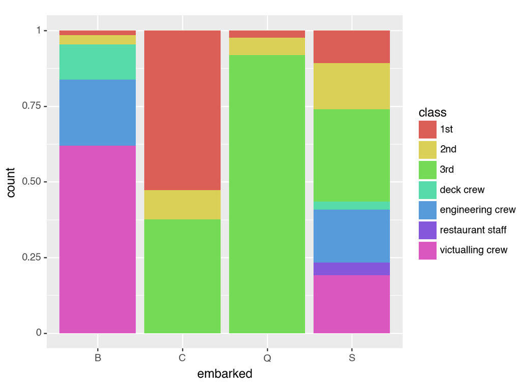

```python
from plotnine import (ggplot, geom_bar, aes)

(ggplot(df_titanic,
aes(
  x = "embarked",
  fill = "class"
))
+ geom_bar(position = "fill")
)
```

The visualization above is much more engaging, while comparing the size of the distributions within each embarkation location is better than a standard table. However, it is nearly impossible to find the exact count for each with this graph.